# Time Series Analysis of UPI Data

true

2024-05-02

# **Introduction**

This is just the introductory part of the analysis there are still things i wish to add into this.

## *Here is the datahead*

**Monthly UPI Transaction Value &Volume**

*2016 to 2024*

| Month | No. of Banks live on UPI | Volume(In Mn) | Value(In Cr) | Volume(In Cr) |
| --- | --- | --- | --- | --- |
| 2016-04-01 | 21 | 0 | 0.00 | 0.000 |
| 2016-05-01 | 21 | 0 | 0.00 | 0.000 |
| 2016-06-01 | 21 | 0 | 0.00 | 0.000 |
| 2016-07-01 | 21 | 0.09 | 0.38 | 0.009 |
| 2016-08-01 | 21 | 0.09 | 3.09 | 0.009 |
| 2016-09-01 | 25 | 0.09 | 32.64 | 0.009 |
| 2016-10-01 | 26 | 0.1 | 48.57 | 0.010 |
| 2016-11-01 | 30 | 0.29 | 100.46 | 0.029 |
| 2016-12-01 | 35 | 1.99 | 707.93 | 0.199 |
| 2017-01-01 | 36 | 4.46 | 1696.22 | 0.446 |

*Source*:National Payments Corporation of India (NPCI)

## convertingthe data into a time series object.

```r
val_time<-ts(data=as.numeric(data1$`Value(In Cr)`),start = c(2016,4),end=c(2024,2),deltat = 1/12)
vol_time<-ts(data=as.numeric(data1$`Volume(In Cr)`),start = c(2016,4),end=c(2024,2),deltat = 1/12)
per_trans<-ts(data=val_time/vol_time,start = c(2016,4),end = c(2024,2),deltat=1/12)
```

# Plots

## This plot shows the growth of UPI Transaction volume and Transaction amount overtime(2016-2024)

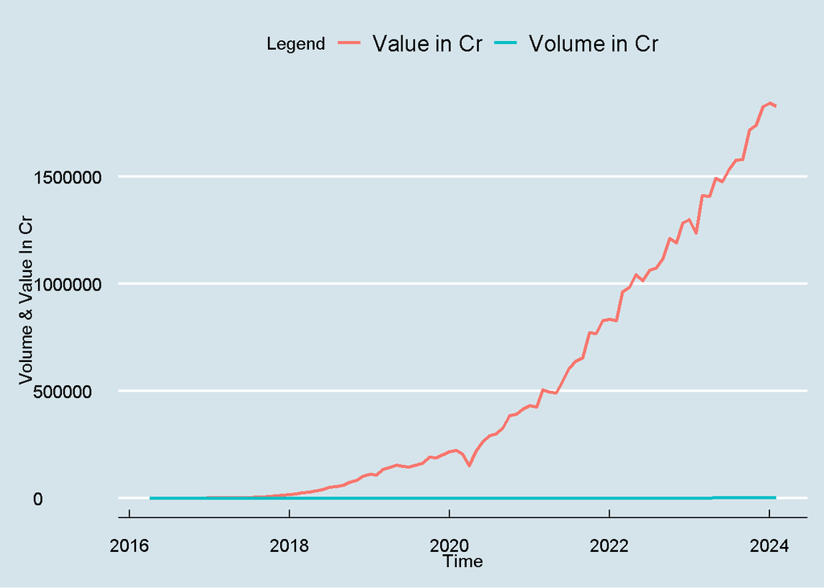

As it can be seen the transaction amounts are much larger than the volume so it is not possible to contain them in the same graph and compare their growth simultaneously. To solve this problem we use the log transformation for both variables to bring them in a comparable range.

## Plot after log transform

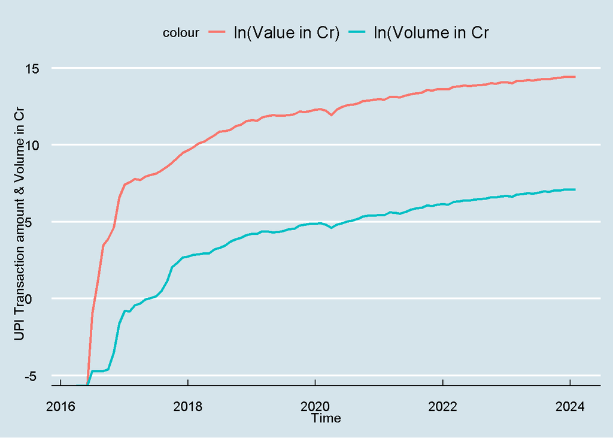

Now we can see the growth of both factors simultaneously and as we would’ve guessed the growth of UPI transaction volume and Transaction Amount is nearly identical even though the difference between their values is very high. This is due to the fact that each individual transaction results in some amount of money being transferred which can range from very small to very high values.

# Linear Regression

## Explaining a linear model

Now the total amount of transactions is the sum of each such individual transaction.Since we do not have data for each individual transaction we do not have a deterministic function to express the total amount as a function of number of transaction. We can write it as a linear model where $y_i$ is transaction amount, $x_i$ is transaction volume ,$\beta$ is some constant factor and $\epsilon$ is random error with 0 mean and some constant variance
$$y_i = \alpha +\beta x_i+\epsilon_i$$

### Correlation between volume and value of transaction.

We can see that the correlation value between $x$=Transaction Volume and $y$=Transaction Amount is :

```
## [1] 0.9967109
```

#### Linear regression summary statistics :

```
##
## Call:
## tslm(formula = val_time ~ vol_time, data = df)
##
## Residuals:
##     Min      1Q  Median      3Q     Max
## -102736  -26456  -15335   32128   93501
##
## Coefficients:
##             Estimate Std. Error t value Pr(>|t|)
## (Intercept) 26456.47    6211.27   4.259  4.9e-05 ***
## vol_time     1561.32      13.16 118.609  < 2e-16 ***
## ---
## Signif. codes:  0 '***' 0.001 '**' 0.01 '*' 0.05 '.' 0.1 ' ' 1
##
## Residual standard error: 46320 on 93 degrees of freedom
## Multiple R-squared:  0.9934, Adjusted R-squared:  0.9934
## F-statistic: 1.407e+04 on 1 and 93 DF,  p-value: < 2.2e-16
```

From the summary data we can see that the adjusted $R^2$ is 0.9934 which shows the model fit is very good.This aligns with our initial assumption and is not a surprising result, This shows that most of the variability in the value of transaction can be explained via the volume of transaction.

# Time Series Analysis

We now move to the main part of our study which is time series analysis of the data.

### Here we have 3 time series objects

- val_time:Value of UPI transactions per month (In Crore,Rupee)
- vol_time:Volume of UPI transactions per month(In crore)
- per trans:Average transaction amount per UPI transaction in each month(In rupee).

**We move our attention to the last object that is per_trans.**

## Plotting the time series

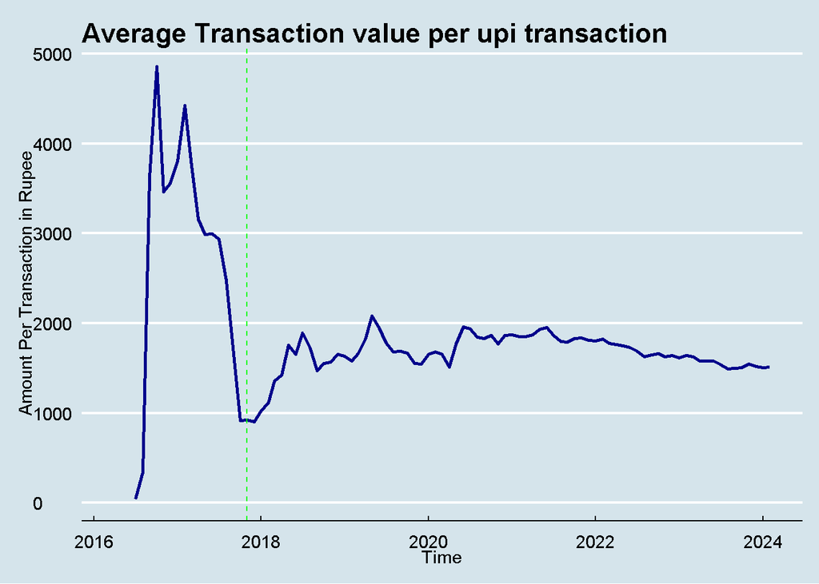

From the plot we can see that the average transaction value between the period of initialization(2016) and unto 2018( *marked by the green dashed line* )has been extremely *high* as during this initial period UPI was used by a selected few individuals. . Overtime with easier access of internet UPI started to become a mainstream method of payment and as the data shows the average transaction value per transaction is *decreasing slowly* this shows as time increases people are using UPI for more and more smaller transactions.

# Decomposing Time series

To do this we use the `decompose()` function in the “stats” package . This function as per the given choice of the model ( *i.e* additive or multiplicative model) breaks down the time series into trend,seasonal and error components using the basic moving average method.

## Decomposing val time

This time series is the monthly total Value of transaction(In Crore. Rupee) in UPI.Here is the decomposed object:

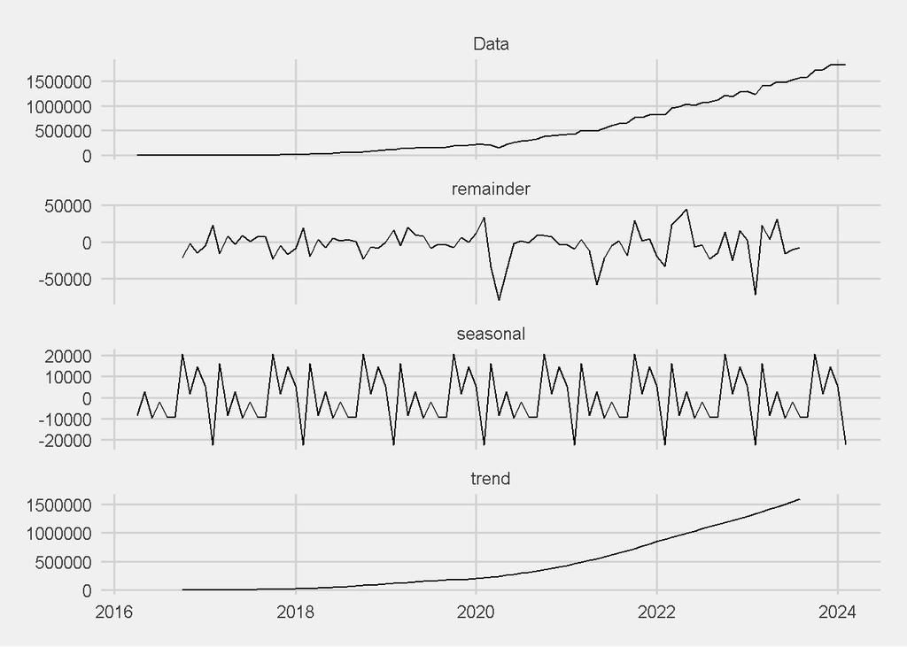

```
##             Jan        Feb        Mar        Apr        May        Jun
## 2016                                   -8440.274   2676.239  -9764.778
## 2017   5454.368 -22669.181  16313.214
##             Jul        Aug        Sep        Oct        Nov        Dec
## 2016  -2197.168  -9081.511  -9474.710  20713.274   1857.261  14613.267
## 2017
```

From the calculated indices we can observe the highest drop in value in February this might be attributed to the fact that February has 28 days which puts it in an obvious disadvantage of 3 days as compared to other months. A surprising find was the decreasing seasonal effects during June,July ,August and September. It could be due to monsoon which hampers business in different ways by limiting human interaction or maybe it’s just because they are close to October which shows a big jump in the transaction values, this due to the high number of festivals during this period. A positive increase is further seen until January. The indices calculated here haven’t been much satisfactory so we may use other methods such as ratio to trend or ratio to moving average to further analyze the data.  
* **Remainder** - The remainder stays somewhat stable until 2020 i.e the variance remains constant up until this period after which there is a spike in the plot and further increase in time shows rather big fluctuations.This unstability of the variance can hamper our forecasts.We can further see if whether or not the random component is normally distributed via a *qq plot* and the famous *Shapiro wilks* test which has the null hypothesis that the data is normally distributed.

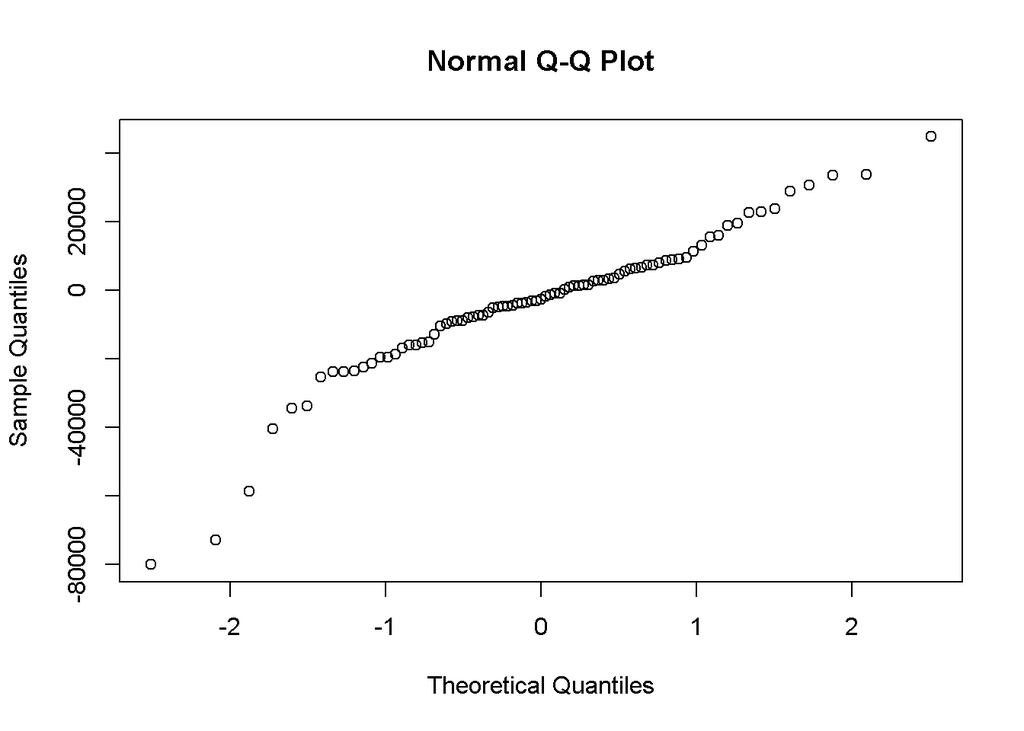

```r
qqnorm(decomp_val$random)
```

```r
shapiro.test(decomp_val$random)
```

```
##
##  Shapiro-Wilk normality test
##
## data:  decomp_val$random
## W = 0.92704, p-value = 0.0001569
```

## Decomposing per_trans

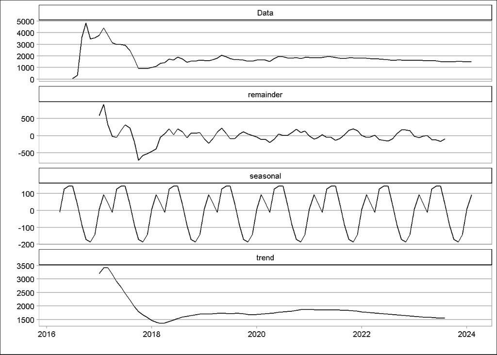

```r
decomp_per<-decompose(per_trans)
autoplot(decomp_per)+theme_calc()
```